# pmlReport

Michael Crocco

March 18, 2016

# Executive Summary

This document is submitted as Prediction Assignment Writeup for the Practical Machine Learning Course offered by Coursera.

Instructor provided data are stored in the working directory and are used to build a machine learning algorithm which predicts the form (or class) of dumbell biceps curl performed based on a wide range of accelerometer inputs. (Class can be A: according to the specification of the exercise, or B through E: each a different, common mistake)

Ultimately, a Random Forest model is selected due to its high Expected Accuracy.

For more detailed information on the dataset, see: Velloso, E.; Bulling, A.; Gellersen, H.; Ugulino, W.; Fuks, H. Qualitative Activity Recognition of Weight Lifting Exercises. Proceedings of 4th International Conference in Cooperation with SIGCHI (Augmented Human ’13) . Stuttgart, Germany: ACM SIGCHI, 2013.

This report will step through the chronology of the analysis.

# 1. Read Data and Look at Format

The training CSV file will be used to create and validate the model, while the testing CSV file is used to create output for the automatically graded quiz.

```r
data <- read.csv("pml-training.csv", header = TRUE)
quiz <- read.csv("pml-testing.csv", header = TRUE)
dim(data) ; dim(quiz)
```

```
## [1] 19622   160
```

```
## [1]  20 160
```

```r
# Print the head of testing data with ID variables, and those defining arm pitch
data[1:5, c("X", "user_name", "raw_timestamp_part_1", "raw_timestamp_part_2", names(data)[grep("pitch_arm$",names(data))], "classe")]
```

```
##   X user_name raw_timestamp_part_1 raw_timestamp_part_2 pitch_arm
## 1 1  carlitos           1323084231               788290      22.5
## 2 2  carlitos           1323084231               808298      22.5
## 3 3  carlitos           1323084231               820366      22.5
## 4 4  carlitos           1323084232               120339      22.1
## 5 5  carlitos           1323084232               196328      22.1
##   avg_pitch_arm stddev_pitch_arm var_pitch_arm skewness_pitch_arm
## 1            NA               NA            NA
## 2            NA               NA            NA
## 3            NA               NA            NA
## 4            NA               NA            NA
## 5            NA               NA            NA
##   min_pitch_arm amplitude_pitch_arm classe
## 1            NA                  NA      A
## 2            NA                  NA      A
## 3            NA                  NA      A
## 4            NA                  NA      A
## 5            NA                  NA      A
```

# 2. Cleaning Data

Looking at the testing data (not shown here), the summary variables are all NA, only the raw accelerations are included. As such, the training data can be subset, eliminating all summary variables. Additionally, the first 7 columns of the data are irrelevant factor variables, so they can be removed at the same time.

```r
emptyColumns <- (colSums(is.na(quiz)) > 0)
subsetData <- data[,!emptyColumns]
subsetData <- subsetData[,-(1:7)]
```

We can now split the training file into a training set and a validation set (the test set will be used as a final output).

```r
set.seed(111)
inTrain <- createDataPartition(subsetData$classe, p=3/4)[[1]]
training <- subsetData[ inTrain,]
testing  <- subsetData[-inTrain,]
```

# 3. Build the Model

## Random Forest

Build a random forest model on the subset data.

```r
set.seed(222)
rf <- randomForest(classe ~ ., data=training, ntree=501, proximity=TRUE, keep.forest=TRUE)
```

# 4. Model Performance Analysis / Validation

```r
rf
```

```
##
## Call:
##  randomForest(formula = classe ~ ., data = training, ntree = 501,      proximity = TRUE, keep.forest = TRUE)
##                Type of random forest: classification
##                      Number of trees: 501
## No. of variables tried at each split: 7
##
##         OOB estimate of  error rate: 0.49%
## Confusion matrix:
##      A    B    C    D    E class.error
## A 4185    0    0    0    0 0.000000000
## B   13 2827    8    0    0 0.007373596
## C    0   14 2550    3    0 0.006622517
## D    0    0   25 2385    2 0.011194030
## E    0    0    1    6 2699 0.002586844
```

### OOB estimate of error rate is less than 1%.

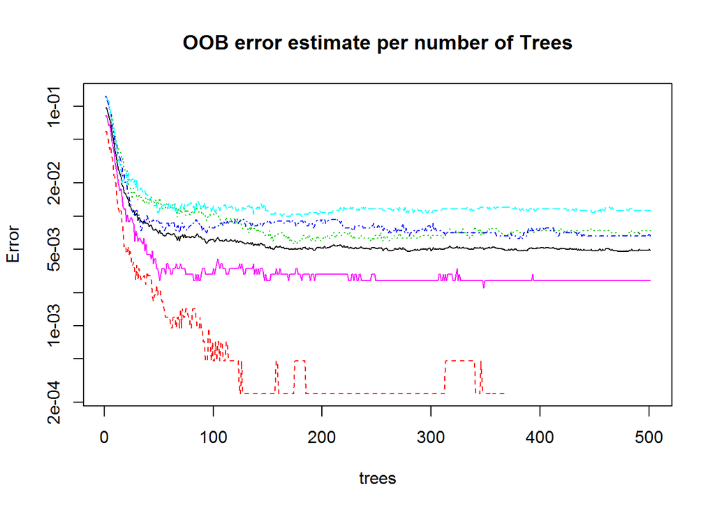

```r
plot(rf, log = "y",main = "OOB error estimate per number of Trees")
```

## Predict Test Set Variables and Check Accuracy

```r
confusionMatrix(predict(rf, newdata=testing),testing$classe)
```

```
## Confusion Matrix and Statistics
##
##           Reference
## Prediction    A    B    C    D    E
##          A 1395    6    0    0    0
##          B    0  942    3    0    0
##          C    0    1  852    6    0
##          D    0    0    0  796    0
##          E    0    0    0    2  901
##
## Overall Statistics
##
##                Accuracy : 0.9963
##                  95% CI : (0.9942, 0.9978)
##     No Information Rate : 0.2845
##     P-Value [Acc > NIR] : < 2.2e-16
##
##                   Kappa : 0.9954
##  Mcnemar's Test P-Value : NA
##
## Statistics by Class:
##
##                      Class: A Class: B Class: C Class: D Class: E
## Sensitivity            1.0000   0.9926   0.9965   0.9900   1.0000
## Specificity            0.9983   0.9992   0.9983   1.0000   0.9995
## Pos Pred Value         0.9957   0.9968   0.9919   1.0000   0.9978
## Neg Pred Value         1.0000   0.9982   0.9993   0.9981   1.0000
## Prevalence             0.2845   0.1935   0.1743   0.1639   0.1837
## Detection Rate         0.2845   0.1921   0.1737   0.1623   0.1837
## Detection Prevalence   0.2857   0.1927   0.1752   0.1623   0.1841
## Balanced Accuracy      0.9991   0.9959   0.9974   0.9950   0.9998
```

### Accuracy is >99%

# 5. Course Quiz

Predict the Values Provided inthe Quiz Data

```r
prediction <- predict(rf, quiz)
prediction
```

```
##  1  2  3  4  5  6  7  8  9 10 11 12 13 14 15 16 17 18 19 20
##  B  A  B  A  A  E  D  B  A  A  B  C  B  A  E  E  A  B  B  B
## Levels: A B C D E
```